# What is the impact of sample size?

### The Impact of Large Sample Sizes

When we increase our sample size, even the smallest of differences may seem significant.

To illustrate this point, work through this notebook and the quiz questions that follow below.

Start by reading in the libraries and data.

```python
import pandas as pd
import numpy as np
import matplotlib.pyplot as plt

%matplotlib inline
np.random.seed(42)

full_data = pd.read_csv('coffee_dataset.csv')
```

`1.` In this case, imagine we are interested in testing if the mean height of all individuals in `full_data` is equal to 67.60 inches or **different** than 67.60. First, use **quiz 1** below to identify the null and alternative hypotheses for these cases.

$$H_0: \mu = 67.60$$ $$H_1: \mu \neq 67.60$$

`2.` Find:

- What is the population mean height?
- What is the standard deviation of the population heights? Create a sample set of data using the code below.
- What is the sample mean height? Simulate the sampling distribution for the mean of five values to see the shape and plot a histogram.
- What is the standard deviation of the sampling distribution of the mean of five draws? Use **quiz 2** below to assure your answers are correct.

```python
sample1 = full_data.sample(5)
sample1
```

|  | user_id | age | drinks_coffee | height |
| --- | --- | --- | --- | --- |
| 469 | 6051 | >=21 | True | 68.717822 |
| 2635 | 3405 | >=21 | True | 69.015309 |
| 1898 | 7983 | <21 | False | 66.418863 |
| 2795 | 6606 | >=21 | True | 69.914371 |
| 167 | 4610 | >=21 | True | 66.670203 |

```python
full_data['height'].mean() #population mean
```

```
67.597486973079342
```

```python
sample1.height.mean() #sample mean
```

```
68.539944261641111
```

```python
np.std(full_data['height'])
```

```
3.1189087116821459
```

```python
np.std(sample1['height'])
```

```
1.3689984227838541
```

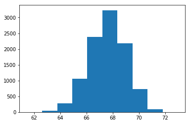

```python
sample_dist = []
for _ in range(10000):
    sample1 = full_data.sample(5)
    sample_mean = sample1.height.mean()
    sample_dist.append(sample_mean)

plt.hist(sample_dist);
```

```python
sample_std_dist = np.std(sample_dist)
sample_std_dist
```

```
1.3955542951565196
```

`3.` Using the null and alternative set up in question 1 and the results of your sampling distribution in question 2, simulate the mean values you would expect from the null hypothesis. Use these simulated values to determine a p-value to make a decision about your null and alternative hypotheses. Check your solution using **quiz 3** and **quiz 4** below.

**Hint:** Use the numpy documentation [here](https://docs.scipy.org/doc/numpy-1.13.0/reference/generated/numpy.random.normal.html) to assist with your solution.

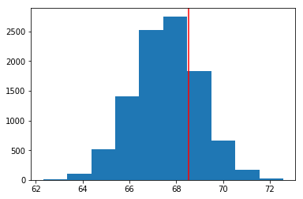

```python
null_mean = 67.60

sample_means = []
for _ in range(10000):
    sample_means.append(sample1)

null_vals = np.random.normal(null_mean, sample_std_dist, 10000)

plt.hist(null_vals);
plt.axvline(x=sample1.height.mean(), color='red');
#visualize where our sample mean lies on our null distribution
```

```python
# for a two sided hypothesis, we want to look at anything
# more extreme from the null in both directions
obs_mean = sample1.height.mean()

# probability of a statistic lower than observed
prob_more_extreme_low = (null_vals < obs_mean).mean()

# probability a statistic is more extreme higher
prob_more_extreme_high = (null_mean + (null_mean - obs_mean) < null_vals).mean()

pval = prob_more_extreme_low + prob_more_extreme_high
pval
```

```
1.4935999999999998
```

`4.` Now, imagine you received the same sample mean you calculated from the sample in question 2 above, but with a sample of 1000.

- What would the new standard deviation be for your sampling distribution for the mean of 1000 values?
- Additionally, what would your new p-value be for choosing between the null and alternative hypotheses you set up? Simulate the sampling distribution for the mean of five values to see the shape and plot a histogram. Use your solutions here to answer the second to last quiz question below.

**Hint:** If you get stuck, notice you can use the solution from the quiz regarding finding the p-value earlier to assist with obtaining this answer with just a few small changes.

`5.` Reflect on what happened by answering the final quiz in this concept.